# Session 2 · From tidy data to insight

R for Data Science · The València Airbnb project

Your name here

2026-10-10

> **Where we are.** Session 1 ended with `listings_clean.rds`. The data pack also provides `calendar_monthly.rds` and `city_month.csv` — the output of HW1’s optional Part D, ready-made so everyone has them. Today: graphics with ggplot2, the EDA loop, and a first model. By the end, answers for our client.

**Today’s route:**

| Block | ⏱ | What we learn |
| --- | --- | --- |
| 1 · Grammar of graphics | 75′ | `ggplot()`: aes, geoms, scales, facets, themes |
| EXTRA · 2 · The EDA loop | 70′ | question → transform → plot → repeat; the calendar data joins in |
| EXTRA · 3 · A first model | 40′ | `lm()`, reading coefficients, the bargain detector |
| 4 · Wrap-up | — | today in one slide, the final project handout |

Blocks marked **EXTRA** are for working through on your own after class.

```r
library(tidyverse)
library(broom)      # tidy model output
library(scales)     # nice axis labels (€, %, thousands)

listings <- read_rds("data/listings_clean.rds")
snapshot_date <- ymd("2026-07-02")
```

# Block 1 · The grammar of graphics ⏱ 75′

Every ggplot is the same sentence: **data + aesthetic mappings + geometry**, plus optional layers that refine it.

```r
ggplot(data = <DATA>) +
  aes(x = <VAR>, y = <VAR>, colour = <VAR>) +   # map variables to visual channels
  geom_<SOMETHING>()                             # draw them
```

## 1.0 · Sixty seconds of geoms

The same sentence with a different `geom_` answers a different kind of question — distribution, comparison, relationship, amount:

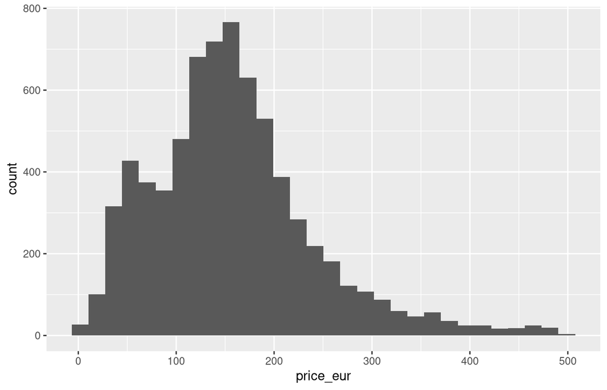

```r
p_data <- listings |> filter(!is.na(price_eur), price_eur < 500)

ggplot(p_data) + aes(x = price_eur) + geom_histogram(bins = 30)       # how is one variable distributed?
```

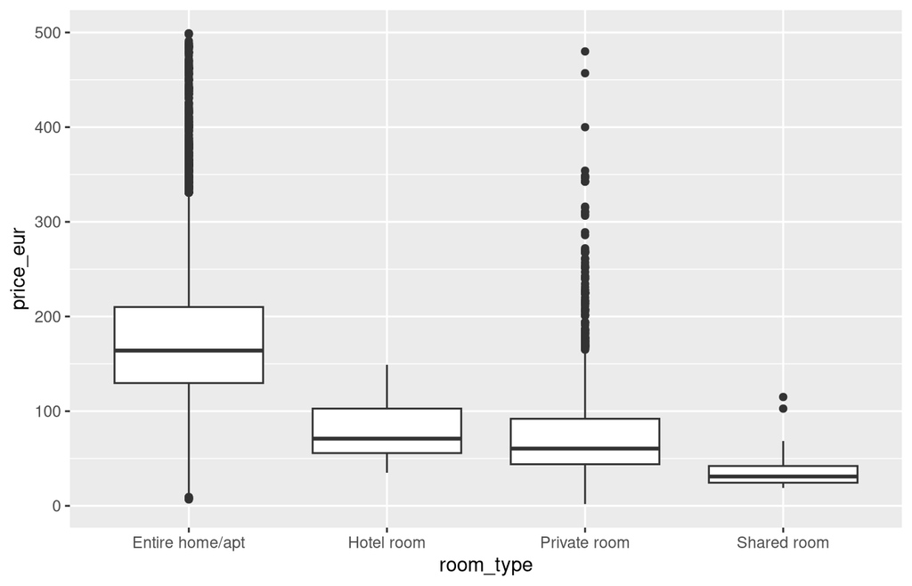

```r
ggplot(p_data) + aes(x = room_type, y = price_eur) + geom_boxplot()   # how does it differ across groups?
```

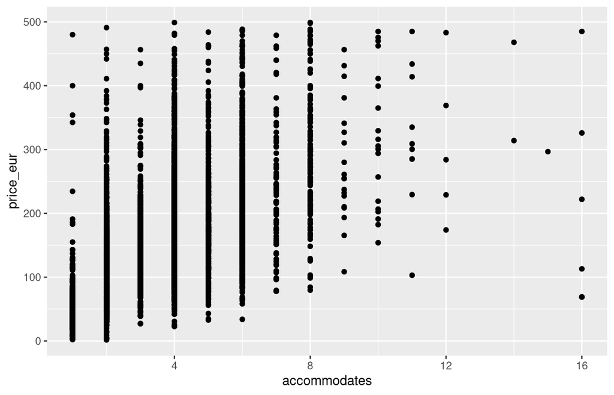

```r
ggplot(p_data) + aes(x = accommodates, y = price_eur) + geom_point()  # how do two variables relate?
```

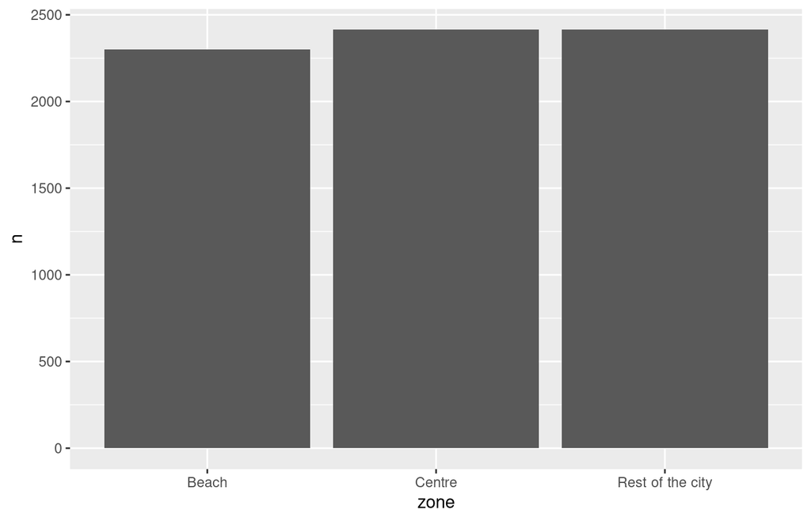

```r
p_data |> count(zone) |>
  ggplot() + aes(x = zone, y = n) + geom_col()                        # how much of each?
```

The geoms you will use most:

```r
geom_histogram()   # distribution of one numeric variable
geom_density()     # its smoothed cousin
geom_boxplot()     # distribution of a number, by group
geom_point()       # scatter: two numeric variables
geom_jitter()      # scatter + a little noise, for overlapping points
geom_line()        # ordered data - time, almost always
geom_col()         # bars with heights you computed
geom_bar()         # bars that count the rows for you
geom_smooth()      # trend line on top of a scatter
geom_text()        # numbers or labels drawn on the plot
```

There are ~50 geoms; the [ggplot2 cheatsheet](https://posit.co/resources/cheatsheets/) is the catalogue. Today we need half a dozen.

## 1.1 · Aesthetics: more channels, more variables

`x` and `y` are only two of the visual channels — the **aesthetics** — a variable can be mapped to. The main ones:

- `x`, `y` — position;
- `colour` — the colour of points, lines and outlines; `fill` — the colour *inside* bars and boxes;
- `size` (points), `linewidth` (lines), `shape` (point symbol), `linetype` (solid/dashed/dotted), `alpha` (transparency).

Map a third variable to one of them and the legend appears on its own:

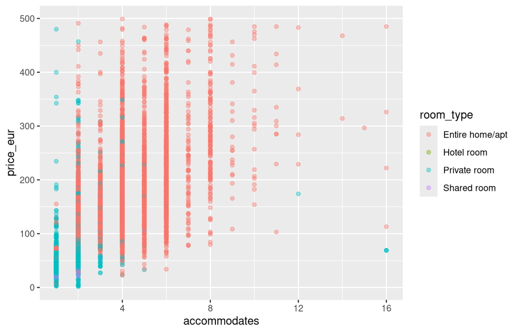

```r
# colour mapped to a category: one colour per room type
ggplot(p_data) +
  aes(x = accommodates, y = price_eur, colour = room_type) +
  geom_point(alpha = 0.4)
```

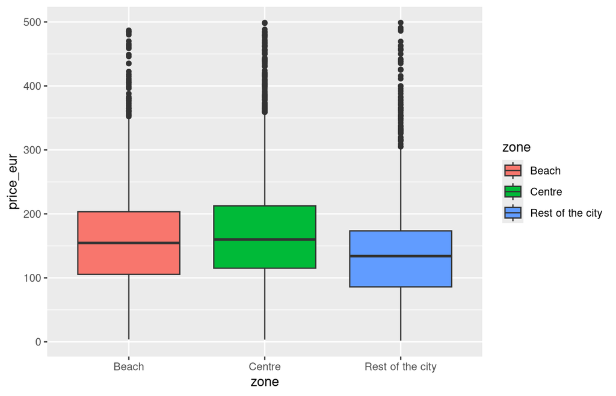

```r
# fill is the "inside" colour - one fill per zone:
ggplot(p_data) +
  aes(x = zone, y = price_eur, fill = zone) +
  geom_boxplot()
```

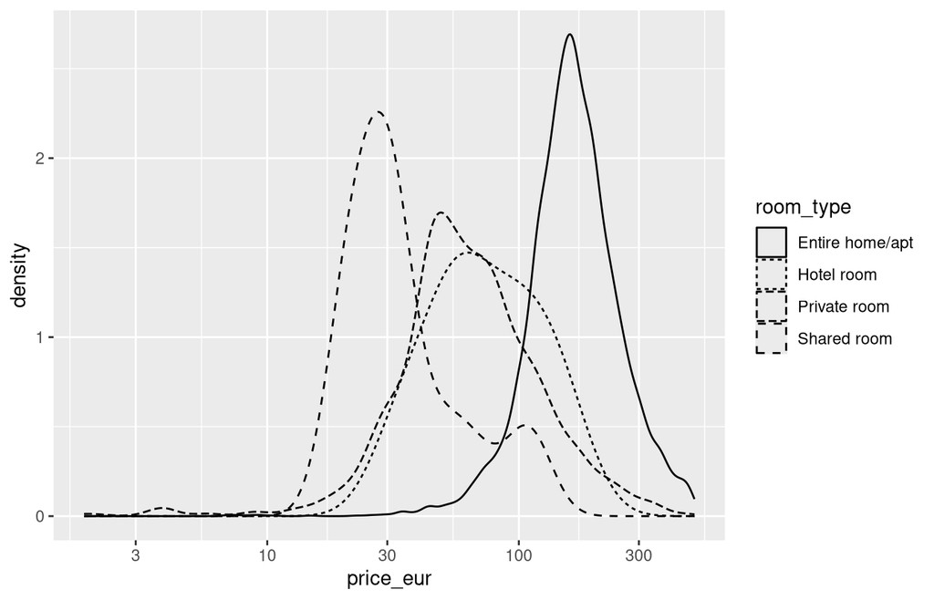

```r
# linetype: tells groups apart even in black and white
# (geom_density = a smoothed histogram)
ggplot(p_data) +
  aes(x = price_eur, linetype = room_type) +
  geom_density() +
  scale_x_log10()
```

One distinction to get right from day one — **mapping** vs **setting**:

- **inside `aes()`** → *mapped*: the channel varies with the data, and gets a legend;
- **outside `aes()`**, as a geom argument → *set*: one constant value for every row;
- the classic bug: `aes(colour = "blue")` maps colour to a “variable” whose value is the word `"blue"`, so you get one default reddish colour plus a useless legend. To paint the points blue, set it outside:

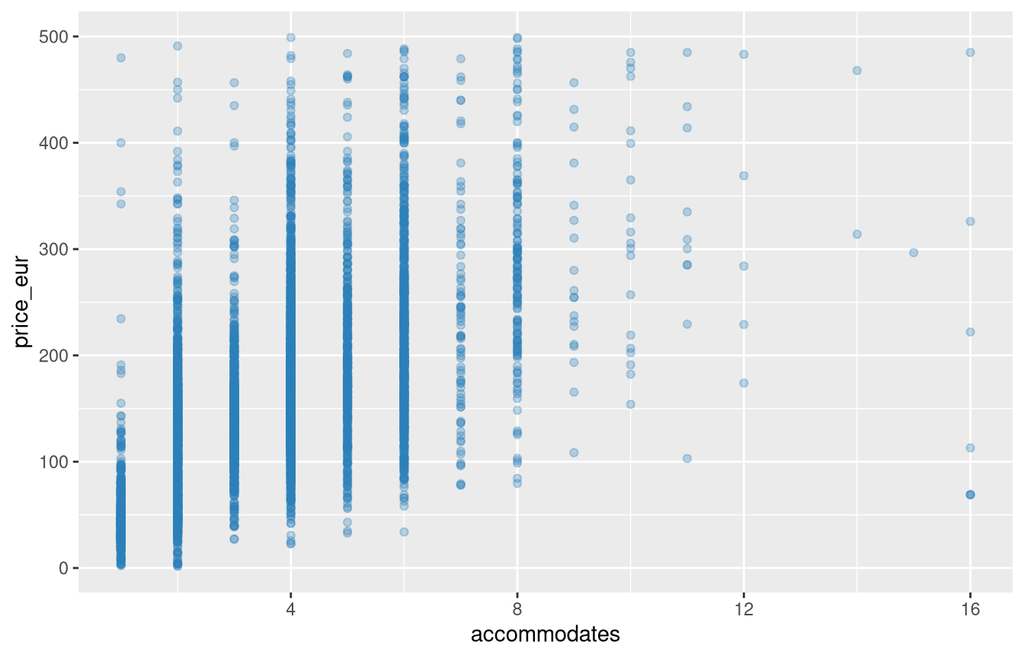

```r
ggplot(p_data) +
  aes(x = accommodates, y = price_eur) +
  geom_point(colour = "#2c7fb8", alpha = 0.3)   # all points: blue, translucent
```

## 1.2 · One variable: distributions

Start with the nightly price:

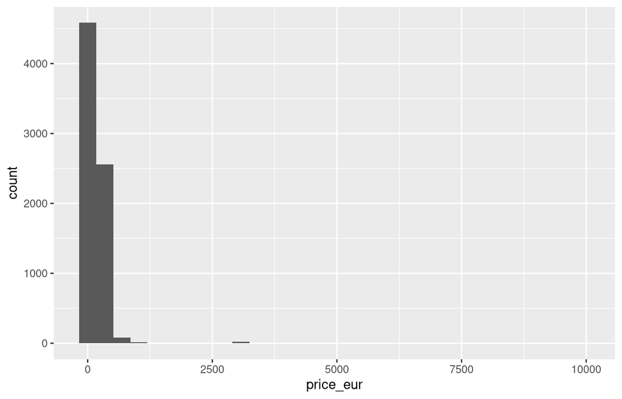

```r
prices <- listings |> filter(!is.na(price_eur))

ggplot(prices) + aes(x = price_eur) + geom_histogram()
```

Unreadable: a few €9,000 listings flatten everything else. Two fixes — **zoom**, or **change the scale**:

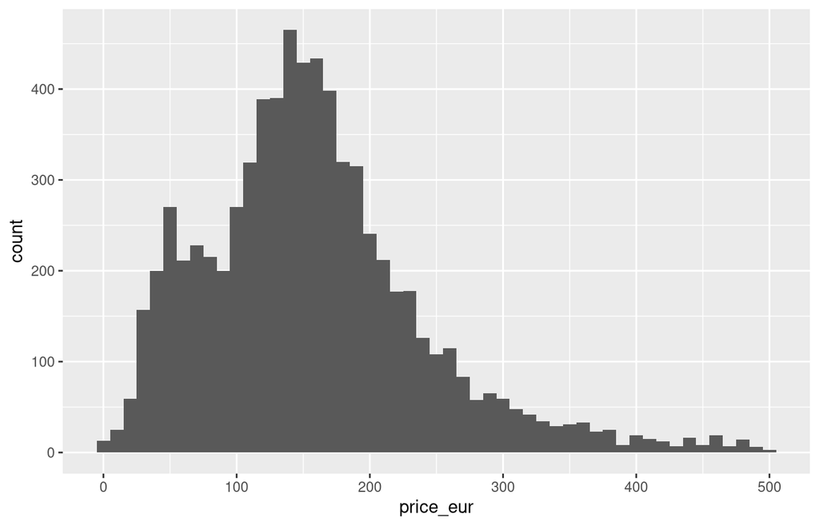

```r
# fix 1: zoom into the market segment we care about
ggplot(prices |> filter(price_eur < 500)) +
  aes(x = price_eur) +
  geom_histogram(binwidth = 10)
```

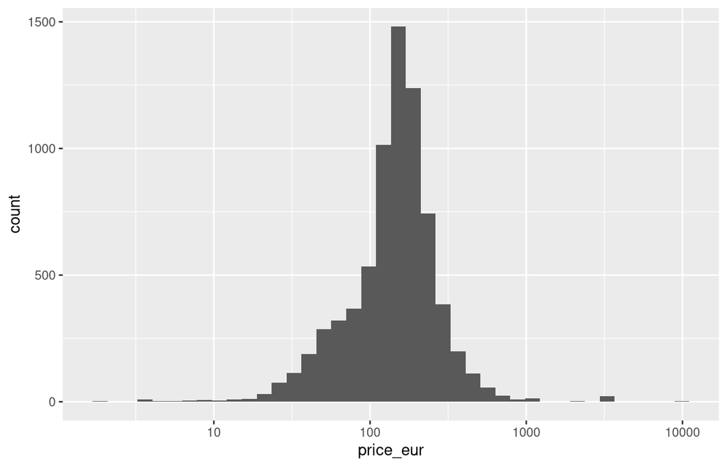

```r
# fix 2: log scale - equal steps = equal *ratios*; right for skewed money data
ggplot(prices) + aes(x = price_eur) + geom_histogram(bins = 40) + scale_x_log10()
```

That last line added something new: a **scale layer**.

- Every aesthetic you map (x, y, colour, fill…) has a *scale*: the rule translating data values into positions or colours on screen.
- You normally don’t see them — ggplot adds sensible defaults silently (`scale_x_continuous()`, …). Writing one yourself **replaces** the default.
- `scale_x_log10()` swaps the x ruler for a logarithmic one: same data, different axis.
- The naming pattern is always `scale_<aesthetic>_<kind>()`.

> The log-scale histogram is nearly symmetric: València prices are roughly **log-normal**. Remember this — it is *why* Block 3 models `log(price)`, not price.

## 1.3 · Two variables: distributions across groups

One numeric variable, one categorical: use a **boxplot**.

- the box spans the middle half of the data; the line inside is the **median**;
- whiskers cover most of the rest; lone dots are outliers;
- map the category to `x`, the number to `y` — one summarised distribution per group, side by side:

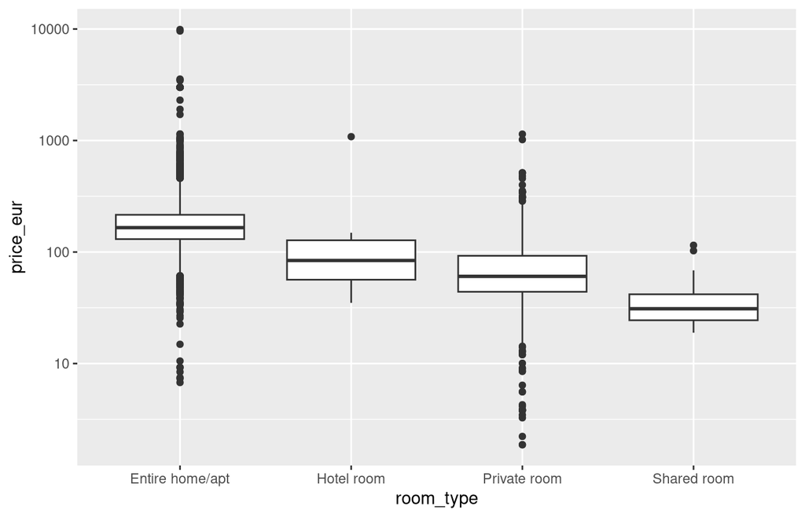

```r
ggplot(prices) +
  aes(x = room_type, y = price_eur) +
  geom_boxplot() +
  scale_y_log10()
```

Categories default to alphabetical order, which is rarely what you want. **forcats** fixes order and crowding:

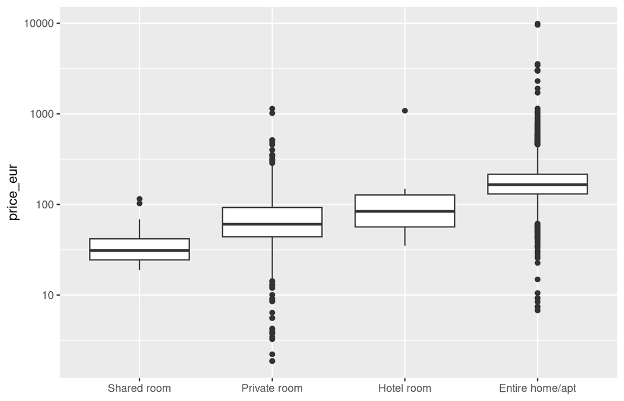

```r
# fct_reorder: order boxes by their median price
ggplot(prices) +
  aes(x = fct_reorder(room_type, price_eur, .fun = median), y = price_eur) +
  geom_boxplot() +
  scale_y_log10() +
  labs(x = NULL)
```

Two more layers before the next chart:

- `labs()` — labels everything: axes (`x =`, `y =`), plot `title`/`subtitle`/`caption`, legends (addressed by their aesthetic: `colour =`, `fill =`); `NULL` removes one;
- `fct_lump_n(f, n)` — keep the `n` most frequent levels, lump the rest into `"Other"`: the fix for an axis with 70 barrios:

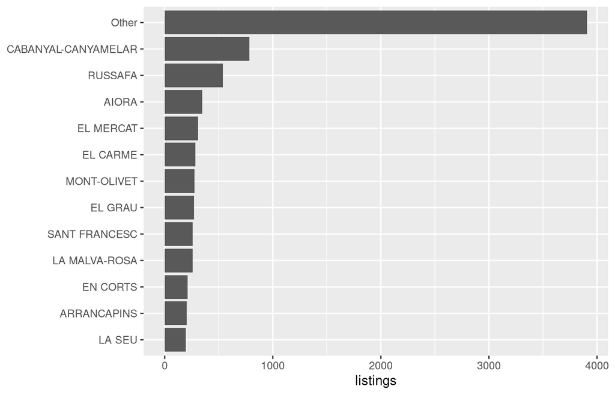

```r
# fct_lump_n + fct_reorder for a barrio bar chart: top 12, ordered, rest lumped
listings |>
  mutate(barrio = fct_lump_n(neighbourhood_cleansed, n = 12)) |>
  count(barrio) |>
  ggplot() +
  aes(x = n, y = fct_reorder(barrio, n)) +      # categories read best on the y axis
  geom_col() +
  labs(y = NULL, x = "listings")
```

## 1.4 · Position: a map with zero GIS

Latitude and longitude are just numbers — a scatter plot *is* a map:

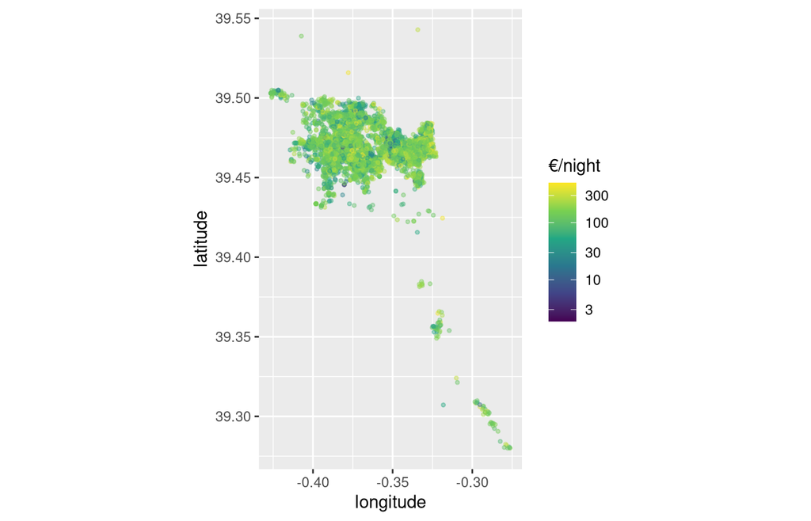

```r
ggplot(prices |> filter(price_eur < 500)) +
  aes(x = longitude, y = latitude, colour = price_eur) +
  geom_point(alpha = 0.4, size = 0.8) +
  scale_colour_viridis_c(trans = "log10") +   # colourblind-safe, perceptually even
  coord_fixed() +
  labs(colour = "€/night")
```

`colour` is an aesthetic like any other, so it has a scale too:

- `scale_colour_viridis_c()` — the **viridis** gradient: perceptually uniform (equal data steps = equal colour steps) and colour-blind-safe;
- the suffix declares the variable type: `_c` continuous (numbers), `_d` discrete (categories);
- `trans = "log10"` — the log trick from 1.2, inside the colour scale. On a linear scale, the typical €40–€150 listings would share a narrow band of purple while a few €500 outliers took the rest of the gradient; on a log scale, doubling the price always moves the colour by the same amount, so ordinary listings get distinguishable colours.

Ciutat Vella and the beach strip stand out immediately.

## 1.5 · Small multiples: `facet_wrap()`

When groups overlap too much in one panel, give each its own:

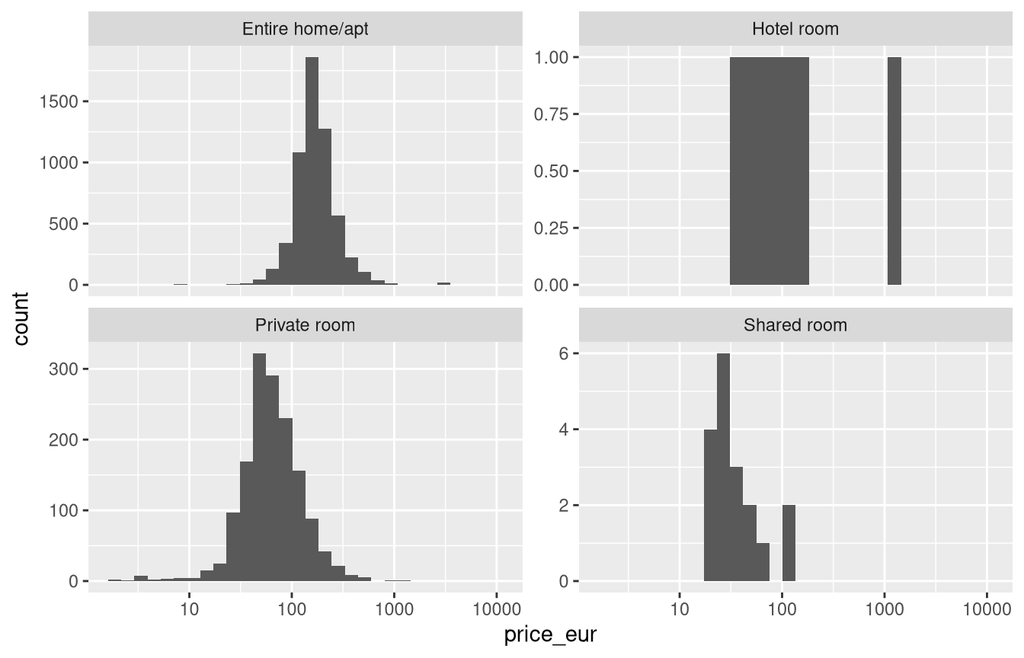

```r
ggplot(prices) +
  aes(x = price_eur) +
  geom_histogram(bins = 30) +
  scale_x_log10() +
  facet_wrap(~ room_type, scales = "free_y")
```

`facet_wrap(~ room_type)` is the third big idea of the grammar: **small multiples**.

- `~ variable` reads “one panel per level of this variable”;
- panels share the same axes by default — that is what makes them comparable at a glance;
- `scales = "free_y"` relaxes exactly that: each panel gets its own y range (x stays shared);
- crossing *two* variables into a grid → `facet_grid(rows ~ cols)`:

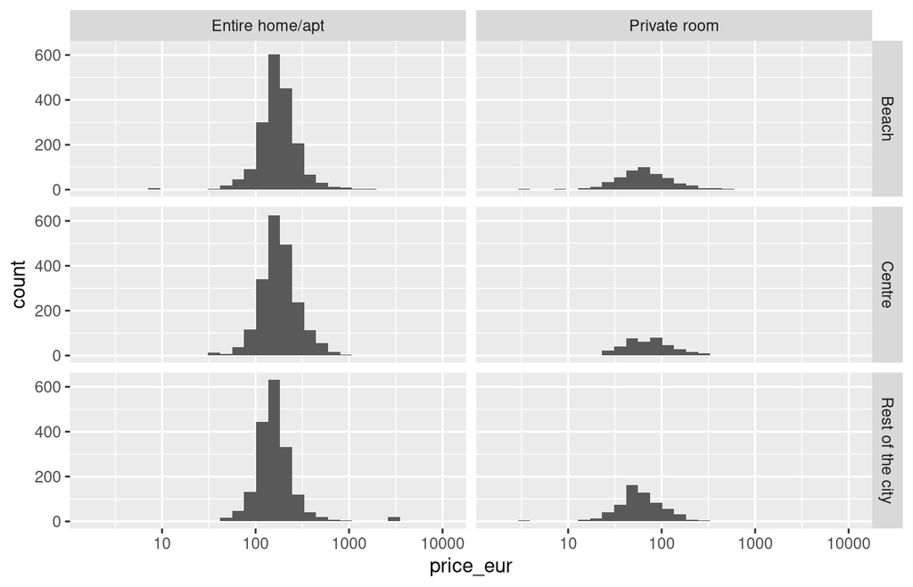

```r
# facet_grid: one ROW per zone, one COLUMN per room type - 3 x 2 = 6 panels
ggplot(prices |> filter(room_type %in% c("Entire home/apt", "Private room"))) +
  aes(x = price_eur) +
  geom_histogram(bins = 30) +
  scale_x_log10() +
  facet_grid(zone ~ room_type)
```

Reading a facet grid: scan down a column to compare zones for one room type, across a row to compare room types within one zone.

🧰 **Sprint toolbox** — the new pieces beyond what you just saw demoed:

| Function | What it does |
| --- | --- |
| `geom_jitter(width = , alpha = )` | a scatter that adds a little random horizontal noise, so points stacked on integer x-values stop hiding each other; `alpha` (0–1) makes points translucent |
| `geom_smooth()` | overlays a fitted trend line (with its uncertainty band) on a scatter |
| `binwidth =` / `bins =` | in `geom_histogram()`: width of each bar / total number of bars |
| `fct_reorder(cat, num, .fun = median)` | reorder a categorical axis by a statistic of another column (from 1.3) |
| `labs(x = , y = , title = )` | label axes and titles; `NULL` removes a label |

**Sprint 1** ⏱ 15:00 — four plots, one insight each. For each: build it, then write ONE sentence of what it says.

1. Histogram of `review_scores_rating` — what shape is it, and why might that be?
2. Boxplots of `price_person` by `zone`, log scale, ordered by median
3. Bar chart: number of listings in the top 10 barrios, ordered, bars horizontal
4. Scatter: `accommodates` vs `price_eur` (log y). Points overlap — fix it (`geom_jitter()`, `alpha`). Add `geom_smooth()` — what does the trend line suggest?

```r
# Your code here
```